# NYPD Shooting Incident Data

2023-10-10

## Purpose of Analysis

The purpose of this analysis is to determine if certain months of the year have more shooting incidents, and if this differs between the sexes.

## Summary of Data and Source

This data comes from data.cityofnewyork.us and is maintained by NYC OpenData.

Per their website, this data is a compilation of “of every shooting incident that occurred in NYC going back to 2006 through the end of the previous calendar year. This data is manually extracted every quarter and reviewed by the Office of Management Analysis and Planning before being posted on the NYPD website. Each record represents a shooting incident in NYC and includes information about the event, the location and time of occurrence. In addition, information related to suspect and victim demographics is also included.”

## 1a. Install Tidyverse Package

```r
## install.packages("tidyverse", repos = "http://cran.us.r-project.org")
library("tidyverse")
```

## 1b. Import Data

This will import and load the necessary data from the source.

```r
## Get current data from data.gov website
url <- "https://data.cityofnewyork.us/api/views/833y-fsy8/rows.csv?accessType=DOWNLOAD"

NYPD_df <- read_csv(url)
NYPD_df
```

```
## # A tibble: 27,312 × 21
##    INCIDENT_KEY OCCUR_DATE OCCUR_TIME BORO     LOC_OF_OCCUR_DESC PRECINCT
##           <dbl> <chr>      <time>     <chr>    <chr>                <dbl>
##  1    228798151 05/27/2021 21:30      QUEENS   <NA>                   105
##  2    137471050 06/27/2014 17:40      BRONX    <NA>                    40
##  3    147998800 11/21/2015 03:56      QUEENS   <NA>                   108
##  4    146837977 10/09/2015 18:30      BRONX    <NA>                    44
##  5     58921844 02/19/2009 22:58      BRONX    <NA>                    47
##  6    219559682 10/21/2020 21:36      BROOKLYN <NA>                    81
##  7     85295722 06/17/2012 22:47      QUEENS   <NA>                   114
##  8     71662474 03/08/2010 19:41      BROOKLYN <NA>                    81
##  9     83002139 02/05/2012 05:45      QUEENS   <NA>                   105
## 10     86437261 08/26/2012 01:10      QUEENS   <NA>                   101
## # ℹ 27,302 more rows
## # ℹ 15 more variables: JURISDICTION_CODE <dbl>, LOC_CLASSFCTN_DESC <chr>,
## #   LOCATION_DESC <chr>, STATISTICAL_MURDER_FLAG <lgl>, PERP_AGE_GROUP <chr>,
## #   PERP_SEX <chr>, PERP_RACE <chr>, VIC_AGE_GROUP <chr>, VIC_SEX <chr>,
## #   VIC_RACE <chr>, X_COORD_CD <dbl>, Y_COORD_CD <dbl>, Latitude <dbl>,
## #   Longitude <dbl>, Lon_Lat <chr>
```

## 2. Tidy and Transform Data

Here, we remove unused columns to clean up the data frame for this analysis. We also check for missing values.

```r
NYPD_df_2 <- NYPD_df %>% select(INCIDENT_KEY,
                                OCCUR_DATE,
                                OCCUR_TIME,
                                BORO,
                                PERP_SEX,
                                VIC_SEX)

lapply(NYPD_df_2, function(x) sum(is.na(x)))
```

```
## $INCIDENT_KEY
## [1] 0
##
## $OCCUR_DATE
## [1] 0
##
## $OCCUR_TIME
## [1] 0
##
## $BORO
## [1] 0
##
## $PERP_SEX
## [1] 9310
##
## $VIC_SEX
## [1] 0
```

```r
NYPD_df_2
```

```
## # A tibble: 27,312 × 6
##    INCIDENT_KEY OCCUR_DATE OCCUR_TIME BORO     PERP_SEX VIC_SEX
##           <dbl> <chr>      <time>     <chr>    <chr>    <chr>
##  1    228798151 05/27/2021 21:30      QUEENS   <NA>     M
##  2    137471050 06/27/2014 17:40      BRONX    <NA>     M
##  3    147998800 11/21/2015 03:56      QUEENS   <NA>     M
##  4    146837977 10/09/2015 18:30      BRONX    <NA>     M
##  5     58921844 02/19/2009 22:58      BRONX    M        M
##  6    219559682 10/21/2020 21:36      BROOKLYN <NA>     M
##  7     85295722 06/17/2012 22:47      QUEENS   <NA>     M
##  8     71662474 03/08/2010 19:41      BROOKLYN <NA>     M
##  9     83002139 02/05/2012 05:45      QUEENS   <NA>     M
## 10     86437261 08/26/2012 01:10      QUEENS   M        M
## # ℹ 27,302 more rows
```

There are several thousand blank values in the **PERP_SEX** column. We will replace the missing values with “X”. This will allow us to distinguish between the “U” values included in the data.

We also convert a few columns to the correct data type. We will also convert the following columns:

- **INCIDENT_KEY:** dbl to chr
- **OCCUR_DATE:** chr to date
- **BORO:** chr to factor
- **PERP_SEX:** chr to factor
- **VIC_SEX:** chr to factor

```r
NYPD_df_3 <- NYPD_df_2 %>%

  replace_na(list(PERP_SEX = "X"))

NYPD_df_3['PERP_SEX'][NYPD_df_3['PERP_SEX'] =="(null)"] <- "X"

NYPD_df_3$INCIDENT_KEY <- as.character(NYPD_df_3$INCIDENT_KEY)
NYPD_df_3$OCCUR_DATE <- mdy(NYPD_df_3$OCCUR_DATE)
NYPD_df_3$BORO <- as.factor(NYPD_df_3$BORO)
NYPD_df_3$PERP_SEX <- as.factor(NYPD_df_3$PERP_SEX)
NYPD_df_3$VIC_SEX <- as.factor(NYPD_df_3$VIC_SEX)

NYPD_df_3
```

```
## # A tibble: 27,312 × 6
##    INCIDENT_KEY OCCUR_DATE OCCUR_TIME BORO     PERP_SEX VIC_SEX
##    <chr>        <date>     <time>     <fct>    <fct>    <fct>
##  1 228798151    2021-05-27 21:30      QUEENS   X        M
##  2 137471050    2014-06-27 17:40      BRONX    X        M
##  3 147998800    2015-11-21 03:56      QUEENS   X        M
##  4 146837977    2015-10-09 18:30      BRONX    X        M
##  5 58921844     2009-02-19 22:58      BRONX    M        M
##  6 219559682    2020-10-21 21:36      BROOKLYN X        M
##  7 85295722     2012-06-17 22:47      QUEENS   X        M
##  8 71662474     2010-03-08 19:41      BROOKLYN X        M
##  9 83002139     2012-02-05 05:45      QUEENS   X        M
## 10 86437261     2012-08-26 01:10      QUEENS   M        M
## # ℹ 27,302 more rows
```

```r
summary(NYPD_df_3)
```

```
##  INCIDENT_KEY         OCCUR_DATE          OCCUR_TIME
##  Length:27312       Min.   :2006-01-01   Length:27312
##  Class :character   1st Qu.:2009-07-18   Class1:hms
##  Mode  :character   Median :2013-04-29   Class2:difftime
##                     Mean   :2014-01-06   Mode  :numeric
##                     3rd Qu.:2018-10-15
##                     Max.   :2022-12-31
##             BORO       PERP_SEX  VIC_SEX
##  BRONX        : 7937   F:  424   F: 2615
##  BROOKLYN     :10933   M:15439   M:24686
##  MANHATTAN    : 3572   U: 1499   U:   11
##  QUEENS       : 4094   X: 9950
##  STATEN ISLAND:  776
##
```

## 3. Add Visualizations and Anlaysis

Here we will analyze the data to determine if certain months of the year have more shooting incidents, and if this differs between the sexes and the boroughs.

```r
NYPD_df_3$MONTH <- (month(NYPD_df_3$OCCUR_DATE, label = TRUE))


NYPD_df_4 <- NYPD_df_3 %>%

  group_by(MONTH)

 NYPD_df_4
```

```
## # A tibble: 27,312 × 7
## # Groups:   MONTH [12]
##    INCIDENT_KEY OCCUR_DATE OCCUR_TIME BORO     PERP_SEX VIC_SEX MONTH
##    <chr>        <date>     <time>     <fct>    <fct>    <fct>   <ord>
##  1 228798151    2021-05-27 21:30      QUEENS   X        M       May
##  2 137471050    2014-06-27 17:40      BRONX    X        M       Jun
##  3 147998800    2015-11-21 03:56      QUEENS   X        M       Nov
##  4 146837977    2015-10-09 18:30      BRONX    X        M       Oct
##  5 58921844     2009-02-19 22:58      BRONX    M        M       Feb
##  6 219559682    2020-10-21 21:36      BROOKLYN X        M       Oct
##  7 85295722     2012-06-17 22:47      QUEENS   X        M       Jun
##  8 71662474     2010-03-08 19:41      BROOKLYN X        M       Mar
##  9 83002139     2012-02-05 05:45      QUEENS   X        M       Feb
## 10 86437261     2012-08-26 01:10      QUEENS   M        M       Aug
## # ℹ 27,302 more rows
```

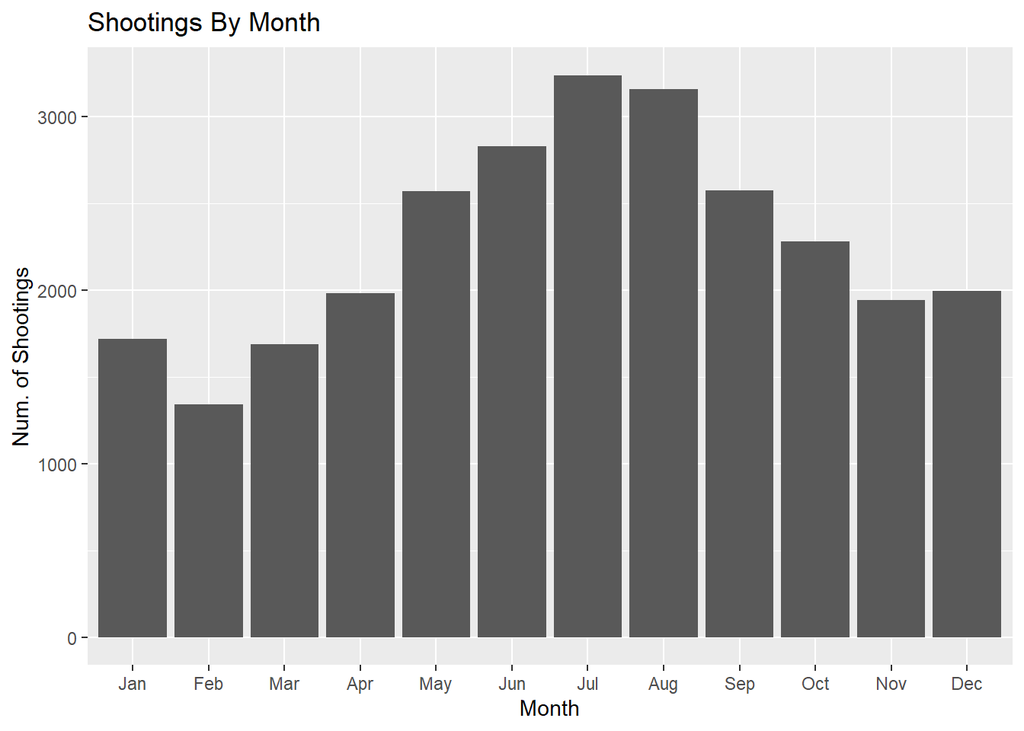

```r
graph_month <- ggplot(NYPD_df_4, aes(x = MONTH)) +
  geom_bar() +
  labs(title = "Shootings By Month",
         x = "Month",
         y = "Num. of Shootings")


graph_month
```

This shows that the highest months for shootings is **July, August and June**, in that order. The lowest months are **February, March and January**, in that order.

```r
NYPD_df_5 <- NYPD_df_3 %>%
  group_by(MONTH, PERP_SEX) %>%

  count()

NYPD_df_5
```

```
## # A tibble: 48 × 3
## # Groups:   MONTH, PERP_SEX [48]
##    MONTH PERP_SEX     n
##    <ord> <fct>    <int>
##  1 Jan   F           28
##  2 Jan   M         1060
##  3 Jan   U           96
##  4 Jan   X          532
##  5 Feb   F           29
##  6 Feb   M          828
##  7 Feb   U           69
##  8 Feb   X          414
##  9 Mar   F           45
## 10 Mar   M         1043
## # ℹ 38 more rows
```

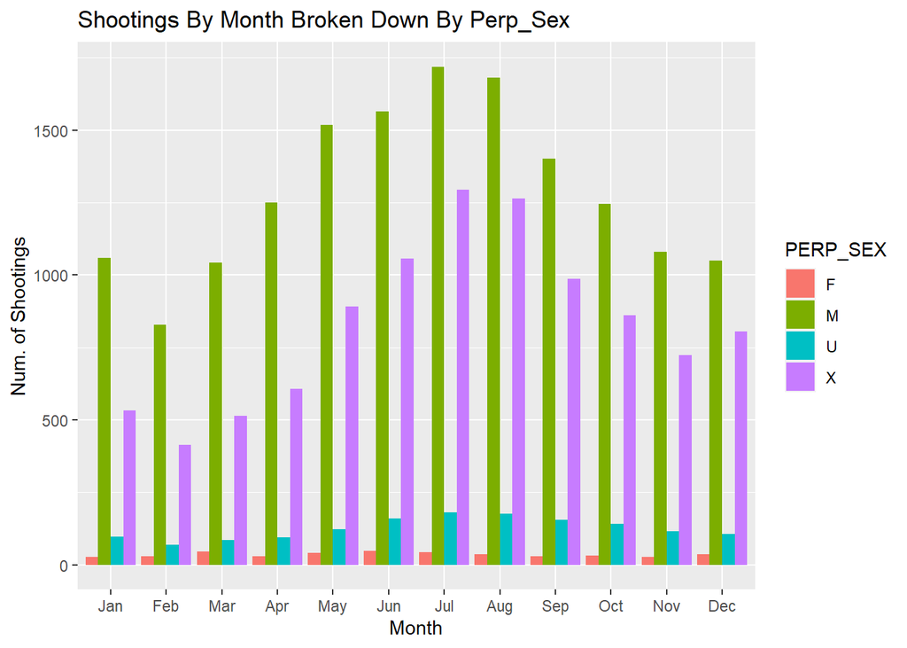

```r
graph_2 <- ggplot(NYPD_df_5, aes(fill = PERP_SEX, y = n, x = MONTH)) +
  geom_bar(position='dodge', stat='identity') +
  labs(title = "Shootings By Month Broken Down By Perp_Sex",
         x = "Month",
         y = "Num. of Shootings")

graph_2
```

When breaking down the shooting by the sex of the perpetrator, it appears that the results are consistent with the overall shootings, in that the summer months have the highest shootings and the winter has the lowest shootings. This brings up additional questions for further research:

- 1. Could this mean that temperature may have something to do with an increase in shootings?
- 2. Also, what months have the highest tourists? Could more vulnerable groups like tourists lead to increased shootings?
- 3. If tourist populations and temperatures coincide with the increase in shootings, what is the relationship between tourists visiting NYC and the weather?

### Where are the Most Dangerous Neighborhoods in NYC?

Now let’s look at the incidents in each borough throughout the year.

```r
NYPD_df_6 <- NYPD_df_3 %>%
  group_by(MONTH, BORO) %>%

  count()

NYPD_df_6
```

```
## # A tibble: 60 × 3
## # Groups:   MONTH, BORO [60]
##    MONTH BORO              n
##    <ord> <fct>         <int>
##  1 Jan   BRONX           536
##  2 Jan   BROOKLYN        614
##  3 Jan   MANHATTAN       245
##  4 Jan   QUEENS          267
##  5 Jan   STATEN ISLAND    54
##  6 Feb   BRONX           381
##  7 Feb   BROOKLYN        493
##  8 Feb   MANHATTAN       188
##  9 Feb   QUEENS          244
## 10 Feb   STATEN ISLAND    34
## # ℹ 50 more rows
```

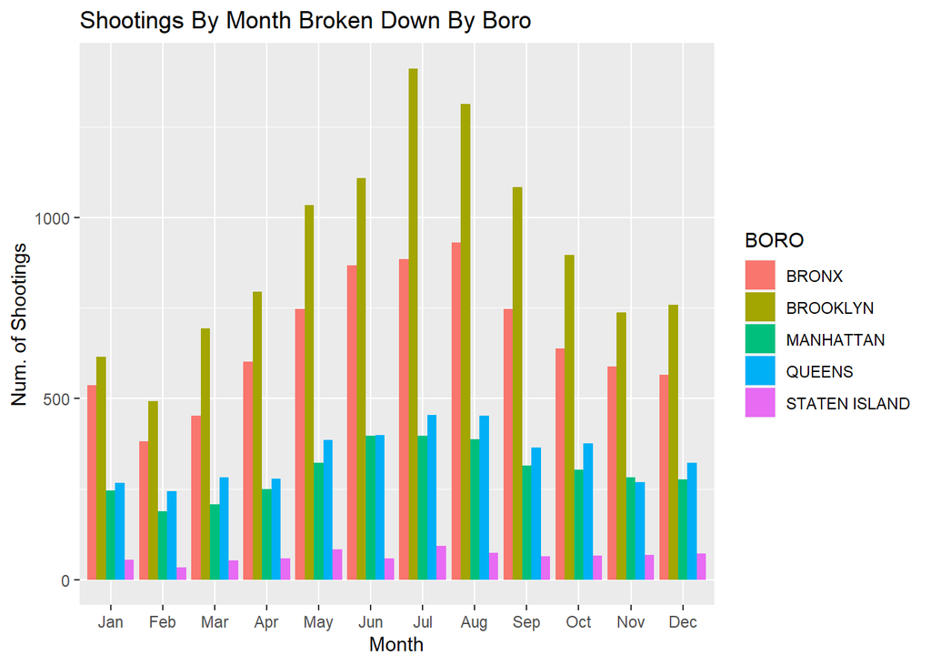

```r
graph_3 <- ggplot(NYPD_df_6, aes(fill = BORO, y = n, x = MONTH)) +
  geom_bar(position='dodge', stat='identity') +
  labs(title = "Shootings By Month Broken Down By Boro",
         x = "Month",
         y = "Num. of Shootings")

graph_3
```

When analyzing the data by borough, the trends are consistent among each other (and with the previous visualizations). All boroughs experience an increase in shootings in the summer and less shootings in the winter. **Brooklyn and the Bronx experience the highest** amount of shootings while **Staten Island and Manhattan see the fewest**. Some additional research questions:

- 1. Does population of the boroughs play a role in the amount of shootings? I.e., researchers should look at the shootings per capita as well as the total shooting incidents.
- 2. Why do some boroughs have fewer or greater shootings? What socio-economic factors contribute to this?

These important questions cannot be answered with the current data set, but would be interesting to dive into and analyze the results!

### What is the most dangerous time of year for each sex in NYC?

To answer this, we need to look at the number of incidents for each victim sex over all months. Below is the graph of incidents for each victim’s sex throughout the year.

```r
NYPD_df_7 <- NYPD_df_3 %>%

  mutate(INCIDENT_KEY = as.numeric(INCIDENT_KEY)) %>%
  group_by(MONTH, VIC_SEX) %>%
  summarize(Incident_Count = n())
NYPD_df_7
```

```
## # A tibble: 31 × 3
## # Groups:   MONTH [12]
##    MONTH VIC_SEX Incident_Count
##    <ord> <fct>            <int>
##  1 Jan   F                  151
##  2 Jan   M                 1565
##  3 Feb   F                  123
##  4 Feb   M                 1217
##  5 Mar   F                  162
##  6 Mar   M                 1525
##  7 Mar   U                    1
##  8 Apr   F                  192
##  9 Apr   M                 1791
## 10 May   F                  235
## # ℹ 21 more rows
```

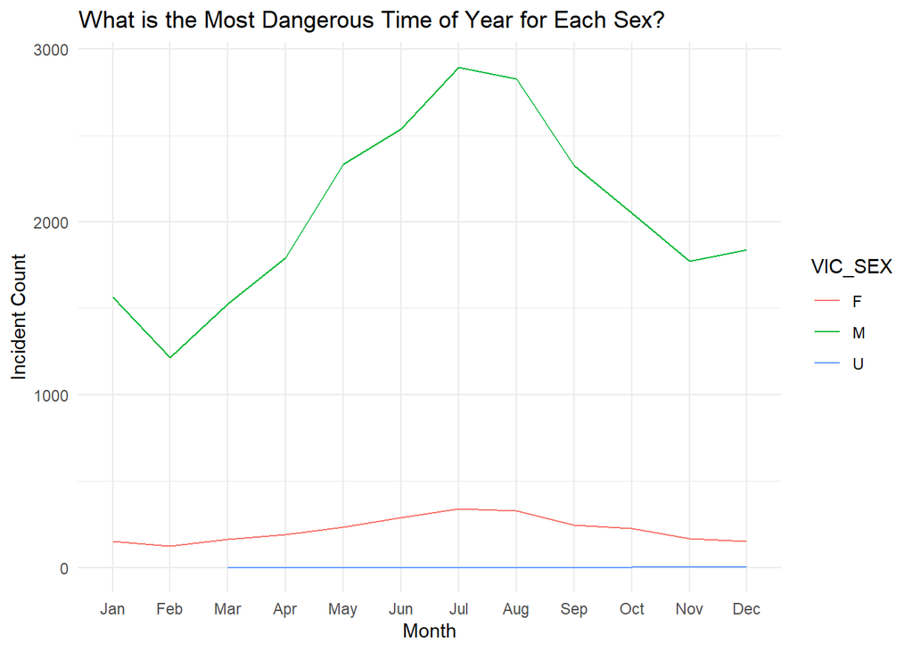

```r
vic_model <- ggplot(NYPD_df_7, aes(x = MONTH, y = Incident_Count, color = VIC_SEX)) +
  geom_line(aes(group = VIC_SEX)) +
  labs(title = "What is the Most Dangerous Time of Year for Each Sex?", x = "Month", y = "Incident Count") + theme_minimal()


vic_model
```

For both Females and Males, the most dangerous time of year is in July, while the safest time of year is in February. Perhaps consider taking the beach vacation this summer instead of trip to the Big Apple, and hold that trip off until the winter!

## 4. Bias Indentification

It is important to check your bias before performing analysis like this, particularly when it comes to sensitive data that involves crimes like this one does. It can be easy for us to tweak our data to fit a narrative that we believe based on personal experiences. I personally have never been to NYC before, so I did not have any pre-conceived notions about where is safe or dangerous. I’m just unfamiliar with the boroughs of NYC. I did however, think that there might be a higher rate of incidents in Nov/Dec time as I figured there would be higher crime around the holidays. Perhaps watching movies like “Home Alone” have played a role into my bias here, but I was glad to see this was not the case. I tried to keep in mind that this was data I was unfamiliar with and therefore could not draw conclusions before analyzing.

Other sources of bias in a data set like this could be that people of a specific race or sex are more likely to commit violence, or are more likely to be a victim. Before analyzing data with factors like this, you must check your bias at the front door to avoid drawing conclusions. Some questions I posed earlier include looking at a more comprehensive view of the incidents, such as if victims were tourists and if weather or socio-economic status plays a role.